# 2. Drug Screening Introduction

Robert Allaway

2020-09-03

# Setup

## Importing libraries for analysis

In this example, we’ll run through some examples of mining publicly available NF drug screening data for interesting features. First, we’ll setup our environment. Then, we’ll get the data, and then we’ll explore it.

To explore the data, we will use a dimensionality reduction technique called umap. This is available both as an R and Python package. In this markdown, we’ll use the R implementation `umap`.

```r
# Sys.setenv('KMP_DUPLICATE_LIB_OK'='TRUE') ##This is a workaround required to knit this markdown properly with umap-learn, suggest removing this line if running as a normal R script.

library(tidyverse) # many helpful data munging functions
library(synapser)
library(umap) ##we'll use umap and dbscan to visualize and cluster the data
library(dbscan)

synLogin()
```

```
## Welcome, Jineta Banerjee!
```

```r
set.seed('90210') ##set a seed for reproducibility
```

## Prepare the drug-target dataset

We’ve already done some of the hard work of mapping NF drug screening IDs together with target data, so we just need to filter down to get a list of targets. We’ll assume everything with a pChEMBL >6 is a “real” target. First, we’ll get the drug IDs and targets for those drugs:

```r
targets <- synGet("syn17091507")$path %>% readRDS() %>%
  filter(mean_pchembl > 6) %>%
  select(internal_id, hugo_gene, std_name) %>%
  distinct()

head(targets)
```

| internal_id | hugo_gene | std_name |
| --- | --- | --- |
| 3 | HTR7 | CHEMBL2413451 |
| 4 | CHRNA4 | CHEMBL204871 |
| 4 | CHRNB2 | CHEMBL204871 |
| 5 | GSK3A | CHEMBL3582401 |
| 6 | FAAH | CHEMBL2386554 |
| 7 | CHRNA7 | CHEMBL3235495 |

## Prepare the drug screening data

In these experiments, researchers treat tumors (or cell lines) with drugs or experimental molecules to figure out whether these tumors are sensitive to these drugs. These compounds have molecular *targets* that the drug binds to and activates or inactivates to affect a biological pathway in the tumors. We’ll take a systematic look at all of these to see if a single NF tumor type - plexiform neurofibroma - is sensitive to any particular drug targets.

This data is standardized across all public NF studies, and a variety of drug metrics were calculated each experiment. These metrics, like IC50, summarize the effect of a drug on a cell line. You can read more about dose-response metrics like IC50s [here](https://www.graphpad.com/support/faq/50-of-what-how-exactly-are-ic50-and-ec50-defined/).

There are a *lot* of diverse measurements in this dataset, so we should do a bit to clean up the data and narrow the scope, and eliminate metrics that might not be that accurate.

Specificially, we will:

-get the dataset

-filter for Simpson AUC. AUC is one measure of cell viability. The lower the cell viability across a range of doses, the lower the AUC. We can use this value because all of the dose-ranges are the same. Note that comparing across different doses can be more difficult.

-filter for NF1 deficient pNF cell lines

-select only the information we need

-`inner_join` on the target dataset to filter out any drugs that we don’t have target info for.

- binarize the target dataset after it has been reduced to only the drugs we can evaluate

```r
drug_data <- synGet("syn20700260")$path %>% read.csv()
head(drug_data)
```

|  | model_name | model_type | cellosaurus_id | organism_name | disease_name | disease_efo_id | symptom_name | symptom_efo_id | experiment_synapse_id | study_synapse_id | funder | drug_name | DT_explorer_internal_id | dosage_unit | drug_screen_id | dosage | response_type | response | response_unit |
| --- | --- | --- | --- | --- | --- | --- | --- | --- | --- | --- | --- | --- | --- | --- | --- | --- | --- | --- | --- |
| 1 | N10 | cell line |  | human | no disease | NA | no symptom | NA | syn11373153.1 | syn5610425 | CTF | GPHR-00000018 | 159129 | uM | 1 | [0.0457246089549396,100] | AUC_Simpson | 35.50878 | NA |
| 2 | N5 | cell line |  | human | NF1 | NA | no symptom | NA | syn11373157.1 | syn5610425 | CTF | GPHR-00000291 | 194936 | uM | 10 | [0.0457246089549396,100] | AUC_Simpson | 4.01805 | NA |
| 3 | N5 | cell line |  | human | NF1 | NA | no symptom | NA | syn11373207.1 | syn5610425 | CTF | GPHR-00101658 | 313081 | uM | 100 | [0.0457246089549396,100] | AUC_Simpson | 23.56699 | NA |
| 4 | N5 | cell line |  | human | NF1 | NA | no symptom | NA | syn11373765.1 | syn5610425 | CTF | GPHR-00224355 | 313317 | uM | 1000 | [0.0457246089549396,100] | AUC_Simpson | 22.77371 | NA |
| 5 | Syn5 | cell line |  | human | NF2 | NA | no symptom | NA | syn12293953.1 | syn2343195 | CTF | NCGC00241342-02 | 150042 | uM | 10000 | [0.00078041474654,46.082949308] | AUC_Simpson | 45.18851 | NA |
| 6 | Syn5 | cell line |  | human | NF2 | NA | no symptom | NA | syn12293953.1 | syn2343195 | CTF | NCGC00241410-01 | 313633 | uM | 10001 | [0.00078041474654,46.082949308] | AUC_Simpson | 47.20716 | NA |

This dataset has many columns, here’s some info about each: model_name: the name of the cells tested in the experiment model_type: always a cell line for this data cellosaurus_id: if cell line is known to cellosaurus, the ID is here organism_name: the organism of the model_name disease_name: the disease modeled by the model disease_efo_id: the experimental factor ontology ID for the disease symptom_name: the symptom modeled by the model symptom_efo_id: the experimental factor ontology ID for the symptom experiment_synapse_id: the source synapse ID for this observation study_synapse_id: the source synapse project for this observation funder: who funded the work drug_name: the source’s name/ID for the drug DT_explorer_internal_id: maps to the internal_id at synapse.org/dtexplorer - can be used to map targets and synonyms of names dosage_unit: the unit of the dosage range drug_screen_id: a unique ID for each dose-response curve dosage: the range of doses tested response_type: the summary metric this row captures response: the value of the summary metric response_unit: if applicable, a unit for the response value

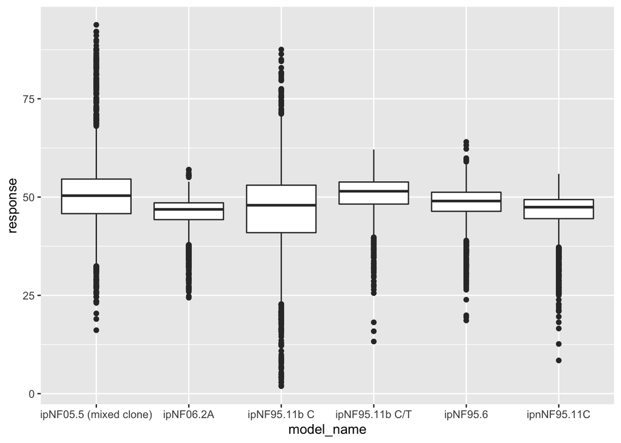

```r
pnf <- c("ipNF05.5", "ipNF06.2A", "ipNF95.11b C/T", "ipnNF95.11C", "ipNF95.6", "ipNF05.5 (mixed clone)", "ipNF95.11b C")

drug_data_filt_1 <- drug_data %>%
  filter(response_type == "AUC_Simpson") %>%
  filter(model_name %in% pnf) %>%
  group_by(drug_screen_id) %>%
  filter(n() == 1) %>%
  ungroup()

ggplot(data = drug_data_filt_1) +
  geom_boxplot(aes(x = model_name, y = response))
```

```r
drug_data_filt <- drug_data_filt_1 %>%
  group_by(DT_explorer_internal_id) %>%
  filter(n() > 3) %>%
  ungroup() %>%
  select(DT_explorer_internal_id, response) %>%
  group_by(DT_explorer_internal_id) %>%
  summarize('median_response' = median(response))%>%
  ungroup()


target_data_filt <- drug_data_filt %>%
  inner_join(targets, by = c("DT_explorer_internal_id" = "internal_id")) %>%
  select(DT_explorer_internal_id, hugo_gene) %>%
  distinct() %>%
  add_column(foo = c(1)) %>%
  spread(hugo_gene, foo, fill = 0) %>%
  column_to_rownames("DT_explorer_internal_id") %>%
  as.matrix()
```

# Dose-response visualization

To get a sense of what this data usually looks like, we can take a look at some specific drugs. mTOR inhibitors are a class of drugs known to inhibit plexiform neurofibromas. KIF11 inhibitors are not associated with this (as far as we know).

Let’s plot a heatmap of the AUCs of all of the MTOR and KIF11 inhibitors in our dataset:

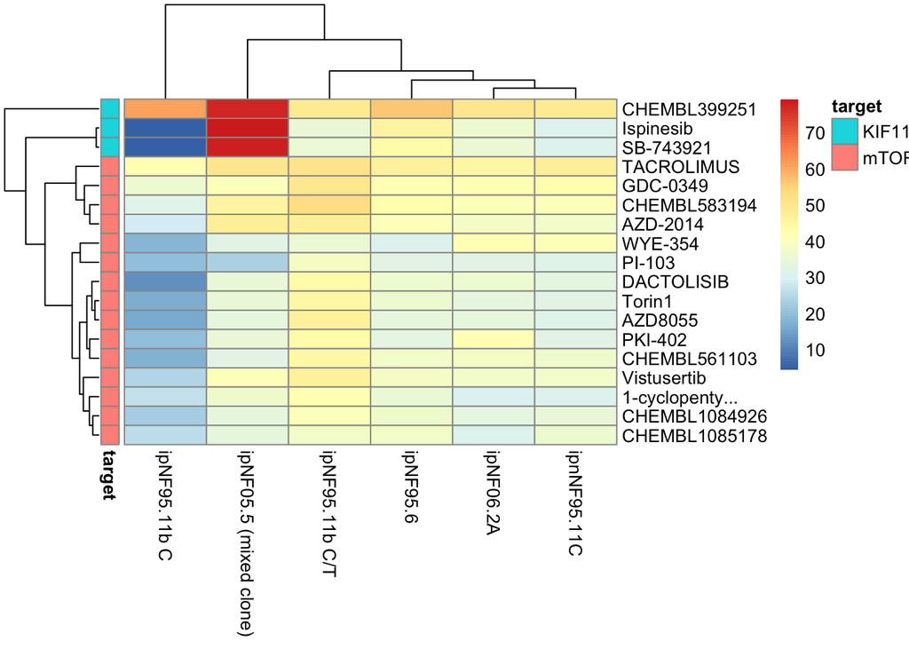

```r
mtor <- targets %>% filter(hugo_gene %in% c("MTOR")) %>% select(internal_id, std_name) %>% distinct() %>% mutate(target = "mTOR")

kif11 <- targets %>% filter(hugo_gene %in% c("KIF11")) %>% select(internal_id, std_name) %>% distinct() %>% mutate(target = "KIF11")

mtor_kif11 <- bind_rows(mtor,kif11) %>% filter(internal_id %in% drug_data_filt_1$DT_explorer_internal_id) %>% mutate(std_name = str_trunc(as.character(std_name),15))

drug_data_filt_heatmap<- drug_data_filt_1 %>%
  filter(DT_explorer_internal_id %in% mtor_kif11$internal_id) %>%
  group_by(model_name, DT_explorer_internal_id) %>%
  summarize('median_response' = median(response))%>%
  ungroup() %>%
  select(model_name, median_response, DT_explorer_internal_id) %>%
  tidyr::spread(model_name, median_response) %>%
  left_join(mtor_kif11, by= c("DT_explorer_internal_id"="internal_id")) %>%
  select(-DT_explorer_internal_id, -target) %>%
  column_to_rownames("std_name")
pheatmap::pheatmap(drug_data_filt_heatmap,
                   annotation_row = mtor_kif11 %>%
                     column_to_rownames("std_name") %>%
                     select(target))
```

It looks like KIF11 targeting drugs and MTOR targeting drugs have a mixture of effects based on the molecule and cell line. Most of these molecules have many targets, not just one, and there’s lots of overlap between molecules. It might be better to map the space of all targets of a drug rather than just look at one at a time. One approach to doing this is to use a dimensionality reduction technique.

## Dimensionality Reduction

Then, we take the binarized target matrix (`target_data_filt`) and use UMAP (`umap`) to reduce the dimensionality of the matrix. This allows us to visualize the grouping. You can learn more about how umap works in the [umap-learn documentation](https://umap-learn.readthedocs.io/en/latest/how_umap_works.html), but it’s sufficient for this markdown to simply understand that we are taking a high-dimension space (drugs with many possible targets) and representing this in two dimensions, similarly to principal components analysis (PCA) or t-stochastic neighbor embedding (t-SNE).

```r
foo <- umap(target_data_filt,
            method = "naive",
            epochs = 2000,
            n_neighbors=4,
            metric = "euclidean",
            random.state = 90210)

foo2 <- foo$layout %>% as.data.frame() %>%
  add_column("DT_explorer_internal_id" = as.integer(rownames(target_data_filt))) %>%
  left_join(drug_data_filt) %>%
  left_join(distinct(select(targets, internal_id, std_name)), by = c("DT_explorer_internal_id" = "internal_id"))
```

## Plot results

Here, we’re looking at the 2 dimensions generated by UMAP. Each point is a drug, it’s position is determined by it’s target profile, and we’ve colored each by the AUC.

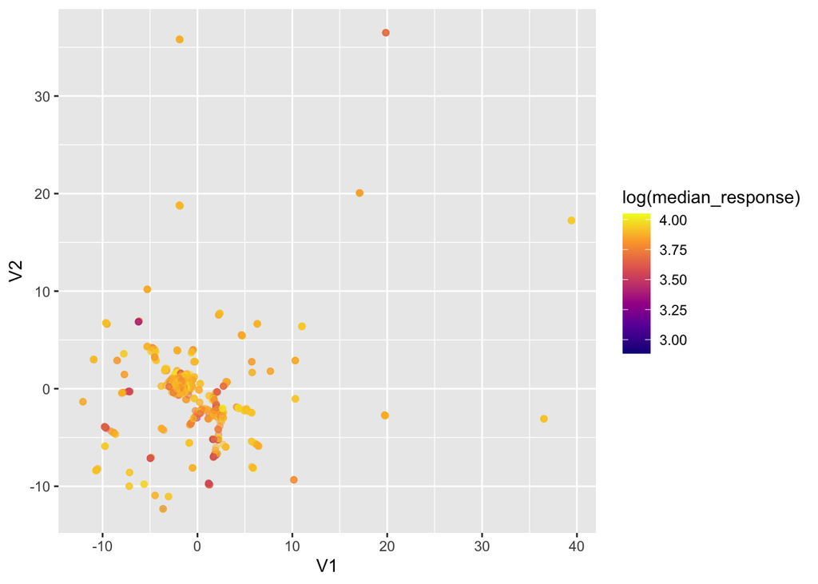

```r
ggplot(foo2) + geom_point(aes(x = V1, y = V2, color = log(median_response)), alpha = 0.5) + scale_color_viridis_c(option = "C")
```

##Plot results with labels

Let’s label the some of the most potent drugs (AUC < 30).

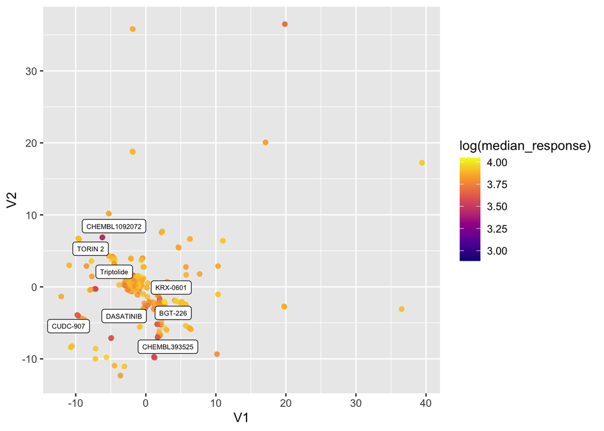

```r
ggplot(foo2) + geom_point(aes(x = V1, y = V2, color = log(median_response)), alpha = 0.5) +
  scale_color_viridis_c(option = "C")  +
  ggrepel::geom_label_repel(data = foo2 %>% filter(median_response < 30), aes(x = V1, y = V2, label = std_name), size = 2)
```

What if we want to identify clusters of drugs with a low median AUC?

```r
foo <- umap(target_data_filt,
            method = "naive",
            epochs = 2000,
            n_neighbors=8,
            metric = "euclidean",
            random.state = 90210)
clusters <- hdbscan(foo$layout, minPts = 3)

foo2 <- foo$layout %>%
  as.data.frame() %>%
  add_column("DT_explorer_internal_id" = as.integer(rownames(target_data_filt))) %>%
  add_column("cluster" = clusters$cluster) %>%
  left_join(drug_data_filt_1) %>%
  group_by(cluster) %>%
  mutate('median_response' = median(response))%>%
  ungroup() %>%
  filter(cluster != 0) %>%
  left_join(distinct(select(targets, internal_id, std_name)), by = c("DT_explorer_internal_id" = "internal_id"))
##this is to look at targets by cluster
#clustarg <- inner_join(foo2, targets) %>% select(cluster, DT_explorer_internal_id, std_name, hugo_gene) %>% distinct()
```

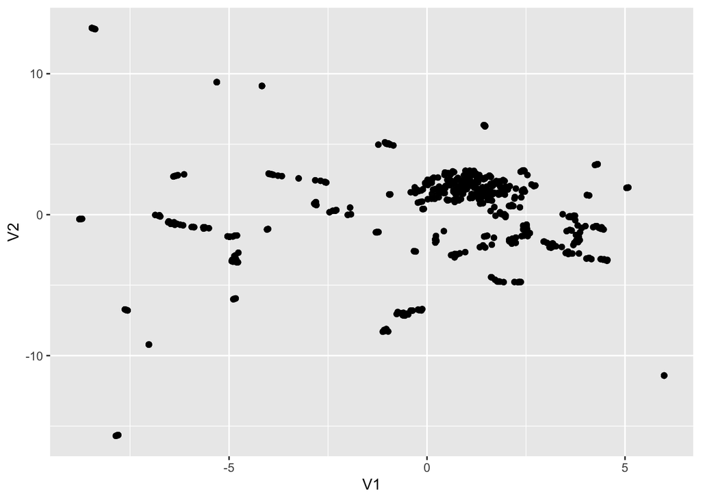

```r
ggplot(foo2) +
  geom_point(aes(x = V1, y = V2), alpha = 0.5) +
  scale_color_viridis_c(option = "D")
```

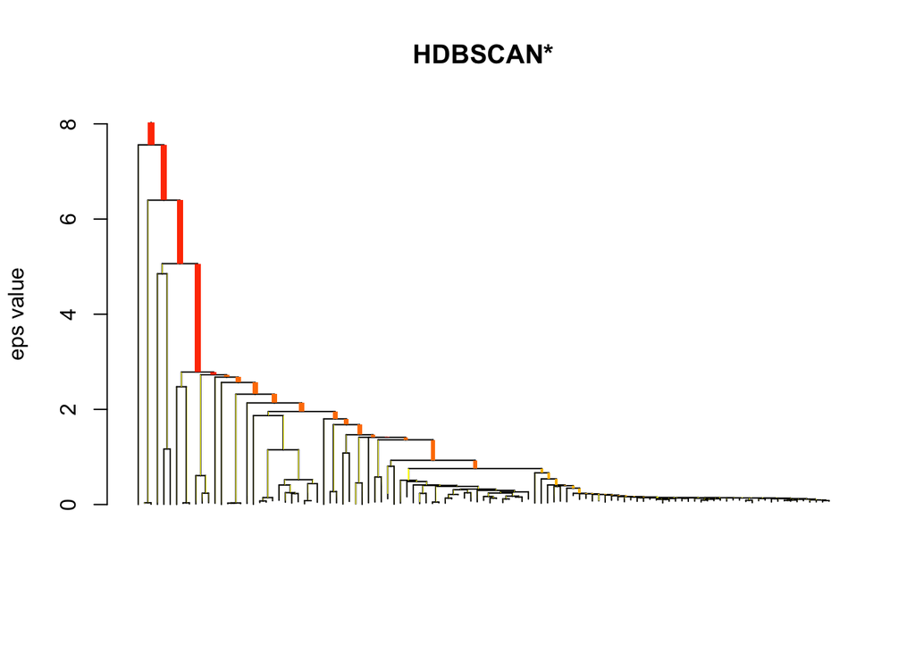

```r
plot(clusters)
```

We can also color the individual clusters as defined by HDBCLUST. There are lots of very close clusters, so this isn’t the most straightforward visualization, but you can get a general sense that the color of the cluster maps closely to the magnitude of the components for each point - i.e. clusters are spatially visible.

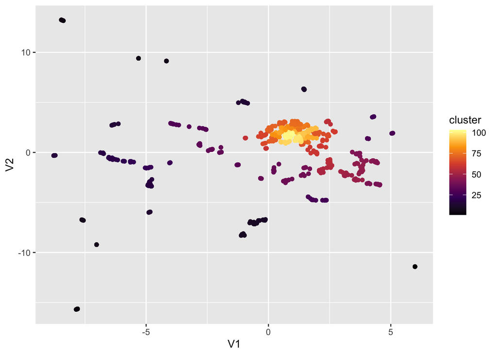

```r
ggplot(foo2) +
  geom_point(aes(x = V1, y = V2, color = cluster), alpha = 0.5) +
  scale_color_viridis_c(option = "B")
```

Finally, we can select for only the best clusters and plot some labels see what drugs are in them Here, I’m filtering only for clusters that have a median AUC < 40 across all cell lines and drugs for that cluster. An important note - this is the *median AUC* for each cluster, so some of these drugs may have had no effect, and that could be masked by the overall cluster average.

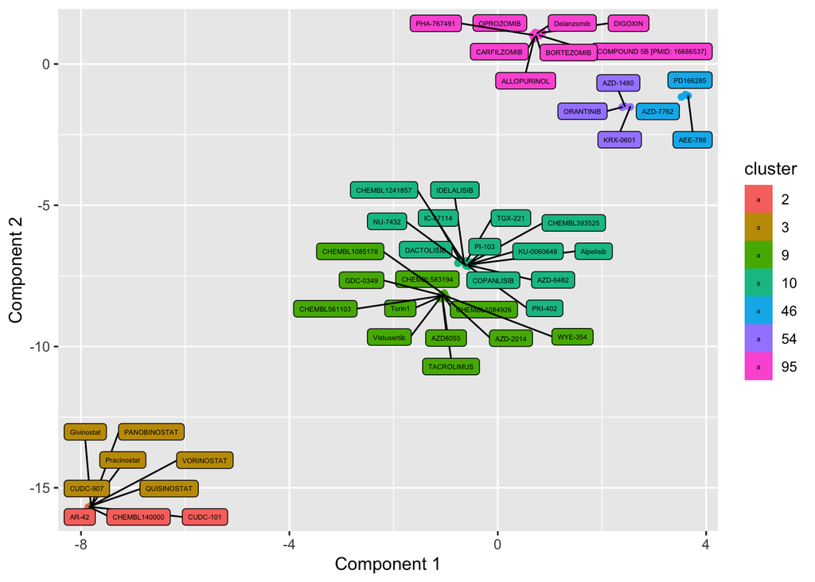

```r
foo3 <- foo2 %>% filter(median_response < 40) %>% mutate(cluster = as.factor(cluster))

ggplot(foo3) +
  geom_point(aes(x = V1, y = V2, color = cluster), alpha = 0.5) +
  ggrepel::geom_label_repel(data = foo3 %>%
                              select(V1,V2,std_name, cluster) %>%
                              distinct(), aes(x = V1, y=V2, label = std_name, fill = cluster), size = 1.5)+
  labs(x = 'Component 1', y = "Component 2")
```